# Reproducible Research Project1

Douglas Wygal

1/22/2020

## Load the Activity Monitoring Data

```r
activity<-read.csv("activity.csv")
```

## What is meant by total number of steps taken per day?

1. Calculate the total number of steps taken per day

```r
steps.day <- tapply(activity$steps, activity$date, sum)
```

2. Make a histogram of the total number of steps taken each day

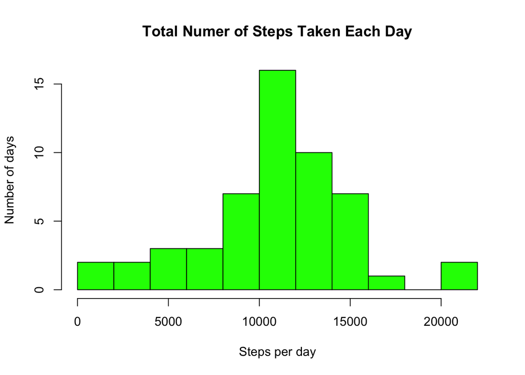

```r
hist(steps.day, main = "Total Numer of Steps Taken Each Day",
     xlab = "Steps per day", ylab = "Number of days",
     breaks = 10, col = "green")
```

3. Calculate and report the mean and median of the total number of steps taken per day

The mean and median of the total number of steps taken per day is 1.076618910^{4} and 10765 respectivily.

## What is the average daily activity pattern?

1. Make a time series plot (i.e. type=“l”) of the 5-minute interval (x-axis) and the average number of steps taken, averaged across all days (y-axis)

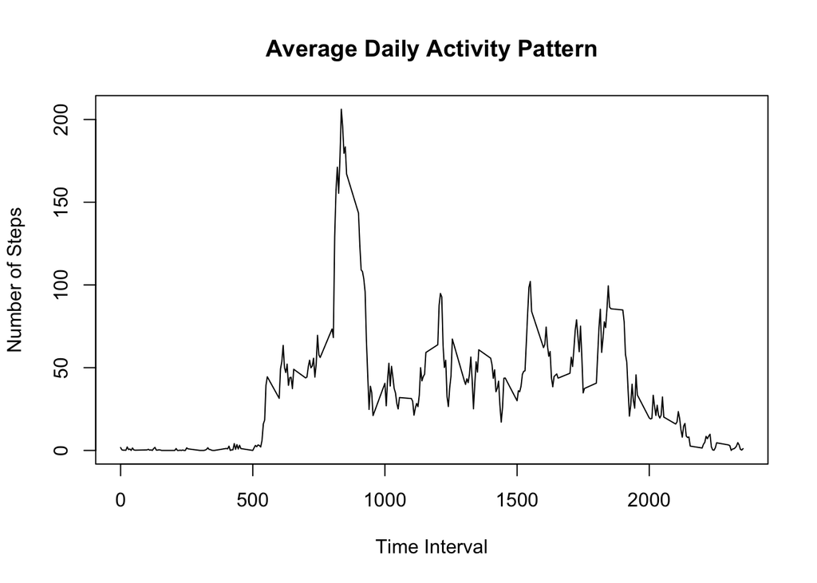

```r
steps.interval<-aggregate(steps~interval,data=activity,FUN=mean,na.action=na.omit)
View(steps.interval)
plot(steps.interval, xlab = "Time Interval", ylab = "Number of Steps",
main = "Average Daily Activity Pattern", type = "l")
```

2. Which 5-minute interval, on average across all the days in the dataset, contains the maximum number of steps?

```r
max.interval<-steps.interval$interval[which.max(steps.interval$steps)]
```

Interval 835 cantains the mazimum number of steps.

## Imput missing values

```r
na.count<-sum(is.na(activity$steps))
```

2. Devise a strategy for filling in all of the missing values in the dataset My plan for filling in missing data with the mean value for each interval. First I created a vector with the with the NAs filled with the values for the mean.

```r
steps.filled<-ifelse(is.na(activity$steps), round(steps.interval$steps[match(
                activity$interval, steps.interval$interval)],0), activity$steps)
```

3. Create a new dataset with the NAs removed

```r
activity2<-data.frame(steps=steps.filled, interval=activity$interval,
                                                            date=activity$date)
```

[figure not shown]

```
Calculate and report the mean and median of the new dataset
```

```r
hist(steps.day, main = "Steps Taken Each Day with NAs Removed",
     xlab = "Steps per day", ylab = "Number of days",
     breaks = 10, col = "blue")
```

```r
steps.filled.day<-tapply(activity2$steps, activity$date, sum)
steps.filled.day.mean <- mean(steps.filled.day, na.rm = TRUE)
steps.filled.day.median <- median(steps.filled.day, na.rm = TRUE)
```

The mean and median of the total number of steps taken per day is 1.076563910^{4} and 1.076210^{4} respectivily.

Do the values differ from the estimates from the first part of the assignment? The values differ from the first dateset but the difference if very little.

What is the impact of imputing missing data on the estimates of total daily number of steps? The impact is very low because of minor changes between the mean and median of each dataset.

## Are there differences in activity patterns between weekdays and weekends?

1. Create a new factor variable in the dataset with two levels - “weekday” and “weekend” indicating whether a given date is a weekday or weekend day.

```r
activity2$FormattedDate <- as.Date(activity2$date, format = "%Y-%m-%d")
# Create daysOfWeek variable
daysOfWeek <- weekdays(activity2$FormattedDate)
# Create weekends variable
activity2$dayType<-ifelse(daysOfWeek %in% c("Saturday", "Sunday"),
                                                          "Weekend", "Weekday")
```

2. Make a panel plot containing a time series plot (i.e. type = “l” type=“l”) of the 5-minute interval (x-axis) and the average number of steps taken, averaged across all weekday days or weekend days (y-axis).

```r
# add the plyr library
library(plyr)
```

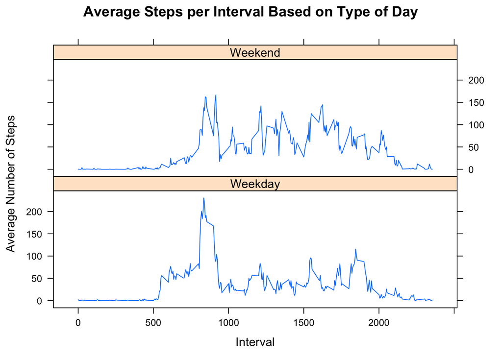

```r
# create the dayTypeDf
dayTypeDf <- ddply(activity2, .(interval, dayType), summarize, Avg = mean(steps))
# add the library lattice
library(lattice)
# create the graph in lattice
xyplot(Avg~interval|dayType, data=dayTypeDf, type="l",  layout = c(1,2),
       main="Average Steps per Interval Based on Type of Day",
       ylab="Average Number of Steps", xlab="Interval")
```